# EDA

Ignacio Vellido Expósito

22/12/2020

# 1 Introducción

Problema de clasificación multiclase.

## 1.1 Problem description

We’re trying to predict the ordinal variable damage_grade, which represents a level of damage to the building that was hit by the earthquake. There are 3 grades of the damage:

1 represents low damage 2 represents a medium amount of damage 3 represents almost complete destruction

The dataset mainly consists of information on the buildings’ structure and their legal ownership. Each row in the dataset represents a specific building in the region that was hit by Gorkha earthquake.

There are 39 columns in this dataset, where the building_id column is a unique and random identifier. The remaining 38 features are described in the section below. Categorical variables have been obfuscated random lowercase ascii characters. The appearance of the same character in distinct columns does not imply the same original value.

Description

- geo_level_1_id, geo_level_2_id, geo_level_3_id (type: int): geographic region in which building exists, from largest (level 1) to most specific sub-region (level 3). Possible values: level 1: 0-30, level 2: 0-1427, level 3: 0-12567.
- count_floors_pre_eq (type: int): number of floors in the building before the earthquake.
- age (type: int): age of the building in years.
- area_percentage (type: int): normalized area of the building footprint.
- height_percentage (type: int): normalized height of the building footprint.
- land_surface_condition (type: categorical): surface condition of the land where the building was built. Possible values: n, o, t.
- foundation_type (type: categorical): type of foundation used while building. Possible values: h, i, r, u, w.
- roof_type (type: categorical): type of roof used while building. Possible values: n, q, x.
- ground_floor_type (type: categorical): type of the ground floor. Possible values: f, m, v, x, z.
- other_floor_type (type: categorical): type of constructions used in higher than the ground floors (except of roof). Possible values: j, q, s, x.
- position (type: categorical): position of the building. Possible values: j, o, s, t.
- plan_configuration (type: categorical): building plan configuration. Possible values: a, c, d, f, m, n, o, q, s, u.
- has_superstructure_adobe_mud (type: binary): flag variable that indicates if the superstructure was made of Adobe/Mud.
- has_superstructure_mud_mortar_stone (type: binary): flag variable that indicates if the superstructure was made of Mud Mortar - Stone.
- has_superstructure_stone_flag (type: binary): flag variable that indicates if the superstructure was made of Stone.
- has_superstructure_cement_mortar_stone (type: binary): flag variable that indicates if the superstructure was made of Cement Mortar - Stone.
- has_superstructure_mud_mortar_brick (type: binary): flag variable that indicates if the superstructure was made of Mud Mortar - Brick.
- has_superstructure_cement_mortar_brick (type: binary): flag variable that indicates if the superstructure was made of Cement Mortar - Brick.
- has_superstructure_timber (type: binary): flag variable that indicates if the superstructure was made of Timber.
- has_superstructure_bamboo (type: binary): flag variable that indicates if the superstructure was made of Bamboo.
- has_superstructure_rc_non_engineered (type: binary): flag variable that indicates if the superstructure was made of non-engineered reinforced concrete.
- has_superstructure_rc_engineered (type: binary): flag variable that indicates if the superstructure was made of engineered reinforced concrete.
- has_superstructure_other (type: binary): flag variable that indicates if the superstructure was made of any other material.
- legal_ownership_status (type: categorical): legal ownership status of the land where building was built. Possible values: a, r, v, w.
- count_families (type: int): number of families that live in the building.
- has_secondary_use (type: binary): flag variable that indicates if the building was used for any secondary purpose.
- has_secondary_use_agriculture (type: binary): flag variable that indicates if the building was used for agricultural purposes.
- has_secondary_use_hotel (type: binary): flag variable that indicates if the building was used as a hotel.
- has_secondary_use_rental (type: binary): flag variable that indicates if the building was used for rental purposes.
- has_secondary_use_institution (type: binary): flag variable that indicates if the building was used as a location of any institution.
- has_secondary_use_school (type: binary): flag variable that indicates if the building was used as a school.
- has_secondary_use_industry (type: binary): flag variable that indicates if the building was used for industrial purposes.
- has_secondary_use_health_post (type: binary): flag variable that indicates if the building was used as a health post.
- has_secondary_use_gov_office (type: binary): flag variable that indicates if the building was used fas a government office.
- has_secondary_use_use_police (type: binary): flag variable that indicates if the building was used as a police station.
- has_secondary_use_other (type: binary): flag variable that indicates if the building was secondarily used for other purposes.

## 1.2 Performance metric

We are predicting the level of damage from 1 to 3. The level of damage is an ordinal variable meaning that ordering is important. This can be viewed as a classification or an ordinal regression problem. (Ordinal regression is sometimes described as an problem somewhere in between classification and regression.)

To measure the performance of our algorithms, we’ll use the F1 score which balances the precision and recall of a classifier.

## 1.3 Submission format

The format for the submission file is two columns with the building_id and the damage_grade. The data type of damage_grade is an integer **with values of 1,2,3**, so make sure there is no decimal point and no other numbers in your submission. For example 1 would be valid, and 1.0 would not.

Referencia:

- https://www.drivendata.org/competitions/57/nepal-earthquake/page/136/#features_list

Cargamos los datos:

```r
train_values <- read_csv("data/train_values.csv")
train_labels <- read_csv("data/train_labels.csv")
test_values  <- read_csv("data/test_values.csv")
```

Quitamos los IDs de fila

```r
train_values.ids <- train_values$building_id
train_values$building_id <- NULL

test_values.ids <- test_values$building_id
test_values$building_id <- NULL

# Guardamos nombres de columna
names <- colnames(train_values)
```

Convertimos a categóricas aquellas que lo son

```r
#  1:3 -> IDs de posición geográfica
factores <- c(1:3,8:26,28:38)

for (i in factores) {
  train_values[[names[i]]] <- train_values[[names[i]]] %>% as.factor()
  test_values[[names[i]]]  <- test_values[[names[i]]] %>% as.factor()
}

# Las etiquetas
train_labels$damage_grade <- train_labels$damage_grade %>% as.ordered()
```

```r
head(train_values)
head(train_labels)
head(test_values)
```

| geo_level_1_id | geo_level_2_id | geo_level_3_id | count_floors_pre_eq | age | area_percentage | height_percentage | land_surface_condition | foundation_type | roof_type | ground_floor_type | other_floor_type | position | plan_configuration | has_superstructure_adobe_mud | has_superstructure_mud_mortar_stone | has_superstructure_stone_flag | has_superstructure_cement_mortar_stone | has_superstructure_mud_mortar_brick | has_superstructure_cement_mortar_brick | has_superstructure_timber | has_superstructure_bamboo | has_superstructure_rc_non_engineered | has_superstructure_rc_engineered | has_superstructure_other | legal_ownership_status | count_families | has_secondary_use | has_secondary_use_agriculture | has_secondary_use_hotel | … |
| --- | --- | --- | --- | --- | --- | --- | --- | --- | --- | --- | --- | --- | --- | --- | --- | --- | --- | --- | --- | --- | --- | --- | --- | --- | --- | --- | --- | --- | --- | --- |
| 6 | 487 | 12198 | 2 | 30 | 6 | 5 | t | r | n | f | q | t | d | 1 | 1 | 0 | 0 | 0 | 0 | 0 | 0 | 0 | 0 | 0 | v | 1 | 0 | 0 | 0 | … |
| 8 | 900 | 2812 | 2 | 10 | 8 | 7 | o | r | n | x | q | s | d | 0 | 1 | 0 | 0 | 0 | 0 | 0 | 0 | 0 | 0 | 0 | v | 1 | 0 | 0 | 0 | … |
| 21 | 363 | 8973 | 2 | 10 | 5 | 5 | t | r | n | f | x | t | d | 0 | 1 | 0 | 0 | 0 | 0 | 0 | 0 | 0 | 0 | 0 | v | 1 | 0 | 0 | 0 | … |
| 22 | 418 | 10694 | 2 | 10 | 6 | 5 | t | r | n | f | x | s | d | 0 | 1 | 0 | 0 | 0 | 0 | 1 | 1 | 0 | 0 | 0 | v | 1 | 0 | 0 | 0 | … |
| 11 | 131 | 1488 | 3 | 30 | 8 | 9 | t | r | n | f | x | s | d | 1 | 0 | 0 | 0 | 0 | 0 | 0 | 0 | 0 | 0 | 0 | v | 1 | 0 | 0 | 0 | … |
| 8 | 558 | 6089 | 2 | 10 | 9 | 5 | t | r | n | f | q | s | d | 0 | 1 | 0 | 0 | 0 | 0 | 0 | 0 | 0 | 0 | 0 | v | 1 | 1 | 1 | 0 | … |

| building_id | damage_grade |
| --- | --- |
| 802906 | 3 |
| 28830 | 2 |
| 94947 | 3 |
| 590882 | 2 |
| 201944 | 3 |
| 333020 | 2 |

| geo_level_1_id | geo_level_2_id | geo_level_3_id | count_floors_pre_eq | age | area_percentage | height_percentage | land_surface_condition | foundation_type | roof_type | ground_floor_type | other_floor_type | position | plan_configuration | has_superstructure_adobe_mud | has_superstructure_mud_mortar_stone | has_superstructure_stone_flag | has_superstructure_cement_mortar_stone | has_superstructure_mud_mortar_brick | has_superstructure_cement_mortar_brick | has_superstructure_timber | has_superstructure_bamboo | has_superstructure_rc_non_engineered | has_superstructure_rc_engineered | has_superstructure_other | legal_ownership_status | count_families | has_secondary_use | has_secondary_use_agriculture | has_secondary_use_hotel | … |
| --- | --- | --- | --- | --- | --- | --- | --- | --- | --- | --- | --- | --- | --- | --- | --- | --- | --- | --- | --- | --- | --- | --- | --- | --- | --- | --- | --- | --- | --- | --- |
| 17 | 596 | 11307 | 3 | 20 | 7 | 6 | t | r | n | f | q | s | d | 0 | 1 | 0 | 0 | 0 | 0 | 0 | 0 | 0 | 0 | 0 | v | 1 | 0 | 0 | 0 | … |
| 6 | 141 | 11987 | 2 | 25 | 13 | 5 | t | r | n | f | q | s | d | 0 | 1 | 0 | 0 | 0 | 0 | 0 | 0 | 0 | 0 | 0 | v | 1 | 1 | 1 | 0 | … |
| 22 | 19 | 10044 | 2 | 5 | 4 | 5 | t | r | n | f | q | s | d | 0 | 1 | 0 | 0 | 0 | 0 | 0 | 0 | 0 | 0 | 0 | v | 1 | 0 | 0 | 0 | … |
| 26 | 39 | 633 | 1 | 0 | 19 | 3 | t | r | x | v | j | t | d | 0 | 0 | 0 | 0 | 0 | 1 | 0 | 0 | 0 | 0 | 0 | v | 2 | 1 | 0 | 0 | … |
| 17 | 289 | 7970 | 3 | 15 | 8 | 7 | t | r | q | f | q | t | d | 0 | 1 | 0 | 0 | 0 | 0 | 0 | 0 | 0 | 0 | 0 | v | 1 | 0 | 0 | 0 | … |
| 22 | 170 | 4029 | 1 | 55 | 4 | 3 | t | r | q | f | j | s | d | 0 | 1 | 0 | 0 | 0 | 0 | 0 | 0 | 0 | 0 | 0 | v | 1 | 0 | 0 | 0 | … |

Guardamos las numéricas por un lado, y el resto por otro

```r
train_values.numeric <- select_if(train_values, is.numeric)
train_values.nonNumeric <- select_if(train_values, negate(is.numeric))

names.numeric <- colnames(train_values.numeric)
names.nonNumeric <- colnames(train_values.nonNumeric)
```

# 2 Análisis univariable

Hacemos summary para sacar datos de relevancia

```r
summary(train_values) %>% unclass() %>% as.data.frame()
```

|  | geo_level_1_id | geo_level_2_id | geo_level_3_id | count_floors_pre_eq | age | area_percentage | height_percentage | land_surface_condition | foundation_type | roof_type | ground_floor_type | other_floor_type | position | plan_configuration | has_superstructure_adobe_mud | has_superstructure_mud_mortar_stone | has_superstructure_stone_flag | has_superstructure_cement_mortar_stone | has_superstructure_mud_mortar_brick | has_superstructure_cement_mortar_brick | has_superstructure_timber | has_superstructure_bamboo | has_superstructure_rc_non_engineered | has_superstructure_rc_engineered | has_superstructure_other | legal_ownership_status | count_families | has_secondary_use | has_secondary_use_agriculture | … |
| --- | --- | --- | --- | --- | --- | --- | --- | --- | --- | --- | --- | --- | --- | --- | --- | --- | --- | --- | --- | --- | --- | --- | --- | --- | --- | --- | --- | --- | --- | --- |
| X | 6 : 24381 | 39 : 4038 | 633 : 651 | Min. :1.00 | Min. : 0.00 | Min. : 1.000 | Min. : 2.000 | n: 35528 | h: 1448 | n:182842 | f:209619 | j: 39843 | j: 13282 | d :250072 | 0:237500 | 0: 62040 | 0:251654 | 0:255849 | 0:242840 | 0:240986 | 0:194151 | 0:238447 | 0:249502 | 0:256468 | 0:256696 | a: 5512 | Min. :0.0000 | 0:231445 | 0:243824 | … |
| X.1 | 26 : 22615 | 158 : 2520 | 9133 : 647 | 1st Qu.:2.00 | 1st Qu.: 10.00 | 1st Qu.: 5.000 | 1st Qu.: 4.000 | o: 8316 | i: 10579 | q: 61576 | m: 508 | q:165282 | o: 2333 | q : 5692 | 1: 23101 | 1:198561 | 1: 8947 | 1: 4752 | 1: 17761 | 1: 19615 | 1: 66450 | 1: 22154 | 1: 11099 | 1: 4133 | 1: 3905 | r: 1473 | 1st Qu.:1.0000 | 1: 29156 | 1: 16777 | … |
| X.2 | 10 : 22079 | 181 : 2080 | 621 : 530 | Median :2.00 | Median : 15.00 | Median : 7.000 | Median : 5.000 | t:216757 | r:219196 | x: 16183 | v: 24593 | s: 12028 | s:202090 | u : 3649 | NA | NA | NA | NA | NA | NA | NA | NA | NA | NA | NA | v:250939 | Median :1.0000 | NA | NA | … |
| X.3 | 17 : 21813 | 1387 : 2040 | 11246 : 470 | Mean :2.13 | Mean : 26.54 | Mean : 8.018 | Mean : 5.434 | NA | u: 14260 | NA | x: 24877 | x: 43448 | t: 42896 | s : 346 | NA | NA | NA | NA | NA | NA | NA | NA | NA | NA | NA | w: 2677 | Mean :0.9839 | NA | NA | … |
| X.4 | 8 : 19080 | 157 : 1897 | 2005 : 466 | 3rd Qu.:2.00 | 3rd Qu.: 30.00 | 3rd Qu.: 9.000 | 3rd Qu.: 6.000 | NA | w: 15118 | NA | z: 1004 | NA | NA | c : 325 | NA | NA | NA | NA | NA | NA | NA | NA | NA | NA | NA | NA | 3rd Qu.:1.0000 | NA | NA | … |
| X.5 | 7 : 18994 | 363 : 1760 | 11440 : 455 | Max. :9.00 | Max. :995.00 | Max. :100.000 | Max. :32.000 | NA | NA | NA | NA | NA | NA | a : 252 | NA | NA | NA | NA | NA | NA | NA | NA | NA | NA | NA | NA | Max. :9.0000 | NA | NA | … |
| X.6 | (Other):131639 | (Other):246266 | (Other):257382 | NA | NA | NA | NA | NA | NA | NA | NA | NA | NA | (Other): 265 | NA | NA | NA | NA | NA | NA | NA | NA | NA | NA | NA | NA | NA | NA | NA | … |

El dataset cuenta con valores repetidos

```r
sum(duplicated(train_values))
```

```
[1] 16191
```

Pero sin missing values (solo NA, quizás haya codificación de missing value con otro valor)

```r
sum(is.na(train_values))
```

```
[1] 0
```

Table de variables numéricas

```r
cat("Age")
table(train_values.numeric$age)
cat("Floors")
table(train_values.numeric$count_floors_pre_eq)
cat("Families")
table(train_values.numeric$count_families)
```

```
Age
    0     5    10    15    20    25    30    35    40    45    50    55    60
26041 33697 38896 36010 32182 24366 18028 10710 10559  4711  7257  2033  3612
   65    70    75    80    85    90    95   100   105   110   115   120   125
 1123  1975   512  3055   847  1085   414  1364    89   100    21   180    37
  130   135   140   145   150   155   160   165   170   175   180   185   190
    9     5     9     3   142     1     6     2     6     5     7     1     3
  195   200   995
    2   106  1390
Floors
     1      2      3      4      5      6      7      8      9
 40441 156623  55617   5424   2246    209     39      1      1
Families
     0      1      2      3      4      5      6      7      8      9
 20862 226115  11294   1802    389    104     22      7      2      4
```

Plots numéricas

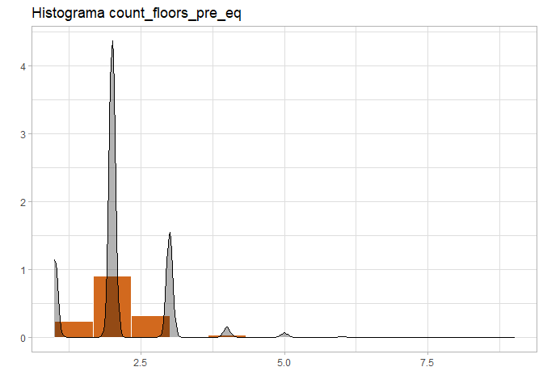

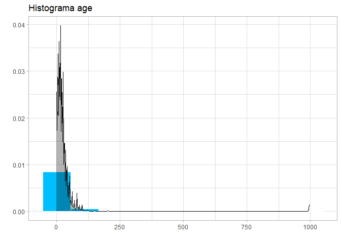

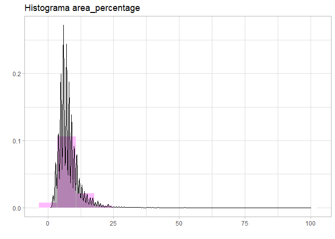

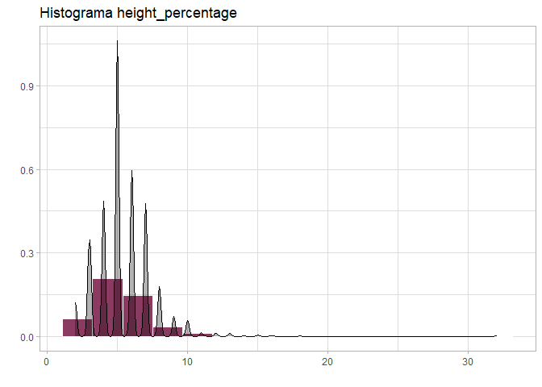

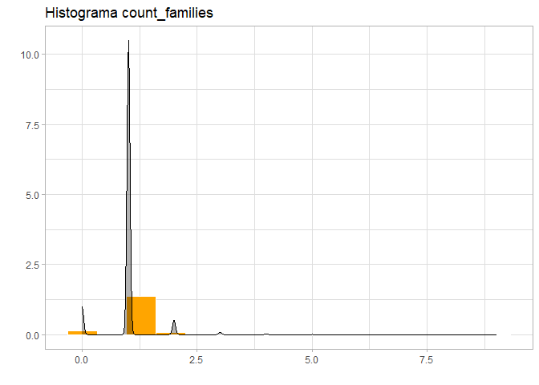

```r
colors <- c("chocolate", "deepskyblue1", "plum1", "hotpink4", "orange", "springgreen4")
bins <- c(13,10,15,15,15)
plt <- list(length = length(names.numeric))

for (i in 1:length(names.numeric)) {
  ggplot(train_values.numeric, aes_string(x=names.numeric[i])) +
    geom_histogram(aes(y=..density..), bins=bins[i], color="white", fill=colors[i]) +
    geom_density(alpha=.3, fill="black", size=.5) +
    labs(title="", x="", y="") +
    theme_light() -> plt[[i]]

  print(plt[[i]] + labs(title=sprintf("Histograma %s", names.numeric[i]), x=""))
}
```

Categóricas

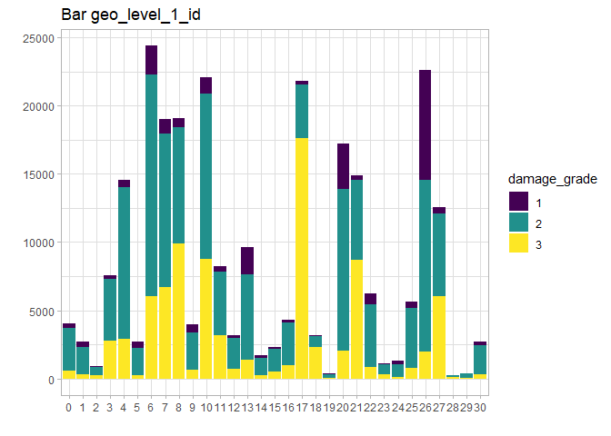

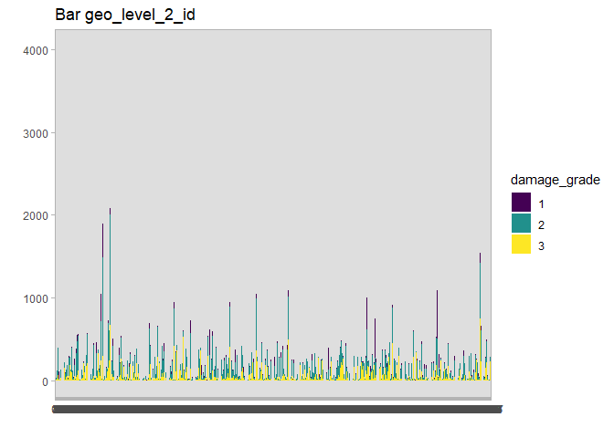

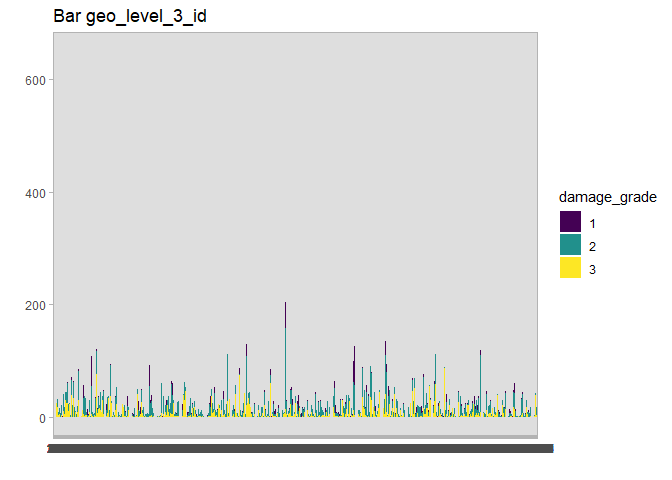

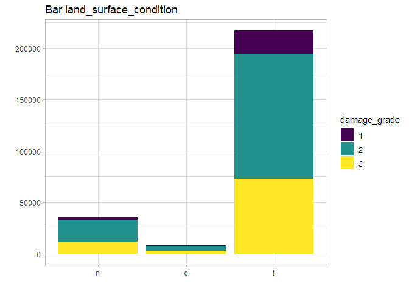

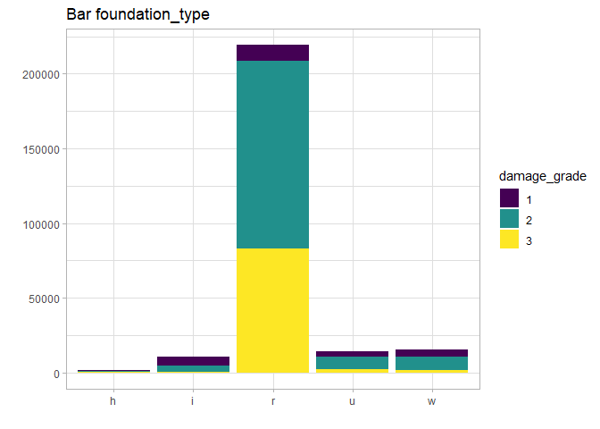

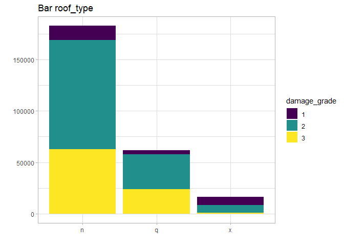

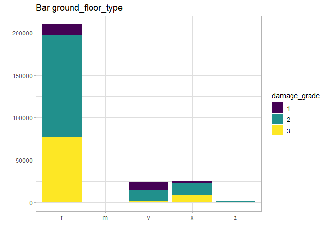

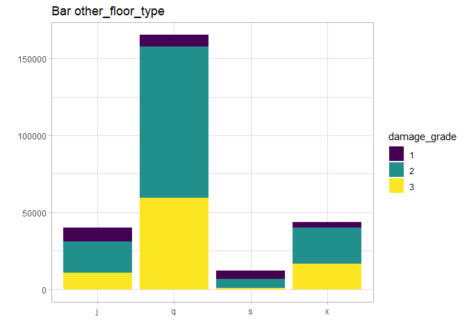

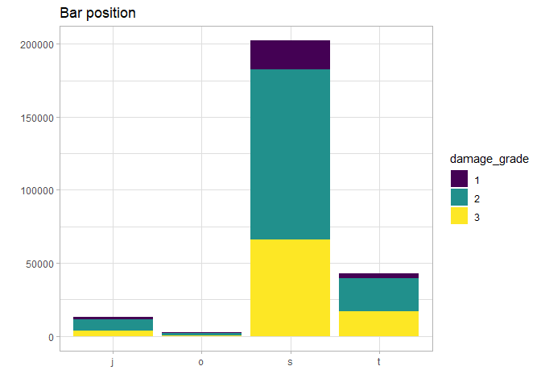

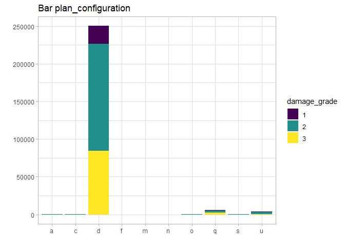

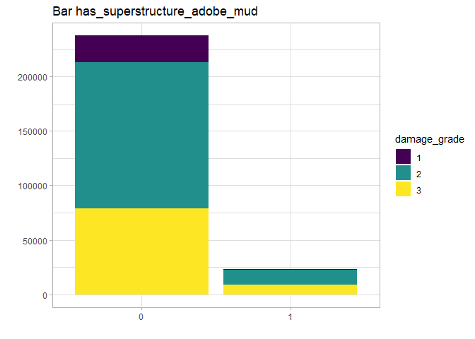

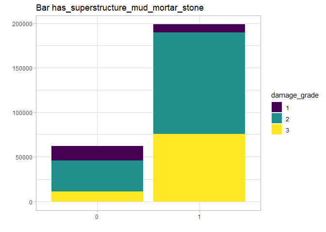

[21 more figures not shown]

```r
colors <- c("chocolate", "deepskyblue1", "plum1", "hotpink4", "orange", "springgreen4")
plt <- list(length = length(names.nonNumeric))

for (i in 1:length(names.nonNumeric)) {
  train_values.nonNumeric[,i] %>%
    bind_cols(train_labels[2]) %>%
    group_by(damage_grade) %>%
    ggplot(aes_string(x=names.nonNumeric[i], fill="damage_grade")) +
      geom_bar() +
      labs(title="", x="", y="") +
      theme_light() -> plt[[i]]

  print(plt[[i]] + labs(title=sprintf("Bar %s", names.nonNumeric[i]), x=""))
}
```

Parece que hay algunas variables categóricas con demasiadas instancias de un tipo

```r
train_values.nonNumeric[,-c(2,3)] %>% apply(2,table)
```

```
$geo_level_1_id

    0     1    10    11    12    13    14    15    16    17    18    19     2
 4011  2701 22079  8220  3194  9608  1714  2320  4332 21813  3189   372   931
   20    21    22    23    24    25    26    27    28    29     3    30     4
17216 14889  6252  1121  1310  5624 22615 12532   265   396  7540  2686 14568
    5     6     7     8     9
 2690 24381 18994 19080  3958

$land_surface_condition

     n      o      t
 35528   8316 216757

$foundation_type

     h      i      r      u      w
  1448  10579 219196  14260  15118

$roof_type

     n      q      x
182842  61576  16183

$ground_floor_type

     f      m      v      x      z
209619    508  24593  24877   1004

$other_floor_type

     j      q      s      x
 39843 165282  12028  43448

$position

     j      o      s      t
 13282   2333 202090  42896

$plan_configuration
```

[output cut: 103 more lines]

```

$has_secondary_use_gov_office

     0      1
260563     38

$has_secondary_use_use_police

     0      1
260578     23

$has_secondary_use_other

     0      1
259267   1334
```

Porcentajes

```r
train_values.nonNumeric[,-c(2,3)] %>%
  apply(2, function(x) {
      t <- round(prop.table(table(x))*100,2)
      print(t)

      if (!is_empty(t[which(t>=90)]))
        print("Quitar columna")
      else {
        cat("Remove: ")
        print(t[which(t<=0.1)])
      }

      cat("-----------------------------")
    }
  )
```

```
x
   0    1   10   11   12   13   14   15   16   17   18   19    2   20   21   22
1.54 1.04 8.47 3.15 1.23 3.69 0.66 0.89 1.66 8.37 1.22 0.14 0.36 6.61 5.71 2.40
  23   24   25   26   27   28   29    3   30    4    5    6    7    8    9
0.43 0.50 2.16 8.68 4.81 0.10 0.15 2.89 1.03 5.59 1.03 9.36 7.29 7.32 1.52
Remove:  28
0.1
-----------------------------x
    n     o     t
13.63  3.19 83.18
Remove: named numeric(0)
-----------------------------x
    h     i     r     u     w
 0.56  4.06 84.11  5.47  5.80
Remove: named numeric(0)
-----------------------------x
    n     q     x
70.16 23.63  6.21
Remove: named numeric(0)
-----------------------------x
    f     m     v     x     z
80.44  0.19  9.44  9.55  0.39
Remove: named numeric(0)
-----------------------------x
    j     q     s     x
15.29 63.42  4.62 16.67
Remove: named numeric(0)
-----------------------------x
    j     o     s     t
 5.10  0.90 77.55 16.46
Remove: named numeric(0)
-----------------------------x
    a     c     d     f     m     n     o     q     s     u
 0.10  0.12 95.96  0.01  0.02  0.01  0.06  2.18  0.13  1.40
[1] "Quitar columna"
-----------------------------x
    0     1
91.14  8.86
[1] "Quitar columna"
-----------------------------x
```

[output cut: 73 more lines]

```
99.98  0.02
[1] "Quitar columna"
-----------------------------x
    0     1
99.99  0.01
[1] "Quitar columna"
-----------------------------x
    0     1
99.99  0.01
[1] "Quitar columna"
-----------------------------x
    0     1
99.49  0.51
[1] "Quitar columna"
-----------------------------NULL
```

Si valor con % >= 90 -> La columna no debería estar aportando mucha información

Si valor con % <= 0.1 -> El elemento apenas aporta

Boxplots

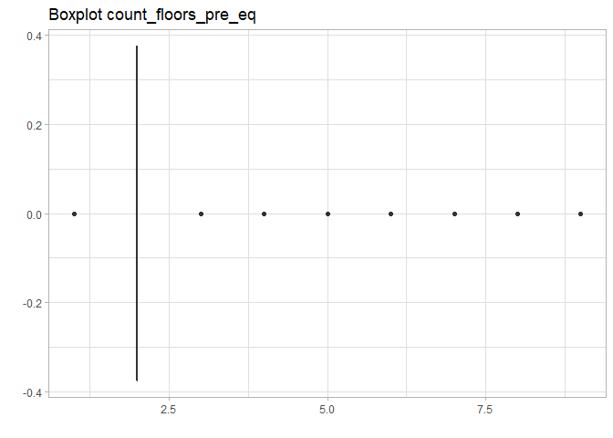

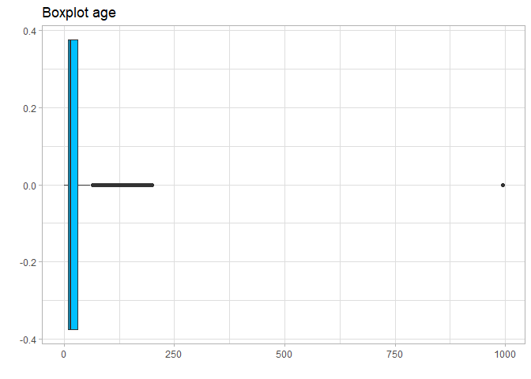

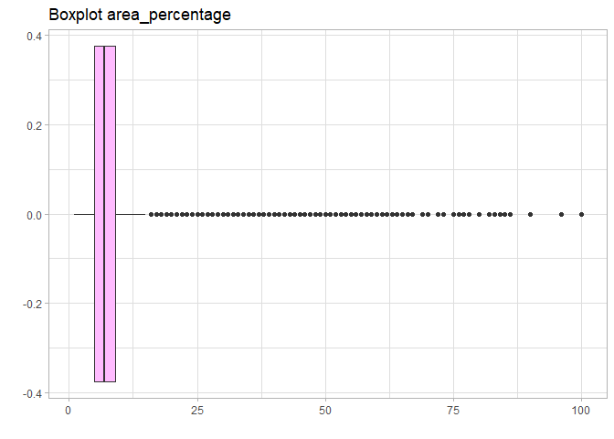

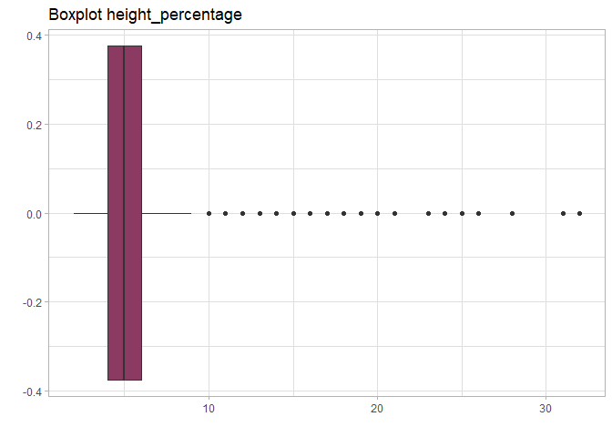

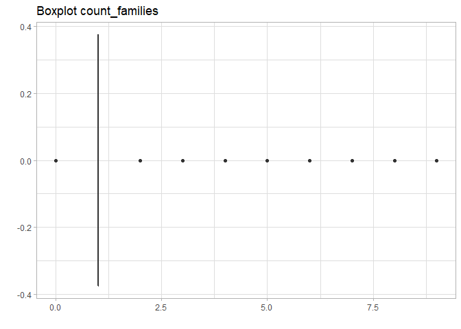

```r
colors <- c("chocolate", "deepskyblue1", "plum1", "hotpink4", "orange", "springgreen4")
plt <- list(length = length(names.numeric))

for (i in 1:length(names.numeric)) {
  ggplot(train_values.numeric, aes_string(x=names.numeric[i])) +
    geom_boxplot(fill = colors[i]) +
    labs(title="", x="", y="") +
    theme_light() -> plt[[i]]

  print(plt[[i]] + labs(title=sprintf("Boxplot %s", names.numeric[i]), x=""))
}
```

Boxplot con mismo rango

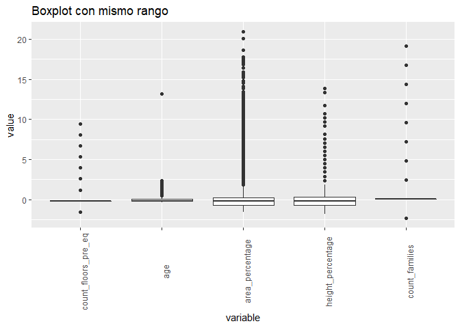

```r
scale(train_values.numeric) %>%
  as.data.frame %>%
  melt() %>%
  ggplot(aes(x=variable, y=value)) +
    geom_boxplot() +
    labs(title="Boxplot con mismo rango") +
    theme(axis.text.x = element_text(angle = 90))
```

Rangos intercuartiles

```r
scale(train_values.numeric) %>% apply(2, IQR)
```

```
count_floors_pre_eq                 age     area_percentage   height_percentage
          0.0000000           0.2718650           0.9106989           1.0425255
     count_families
          0.0000000
```

Distancia entre mínimos y máximos

```r
scale(train_values.numeric) %>% apply(2, range) %>% apply(2, dist)
```

```
count_floors_pre_eq                 age     area_percentage   height_percentage
           10.99408            13.52528            22.53980            15.63788
     count_families
           21.51108
```

Plots primeras instancias

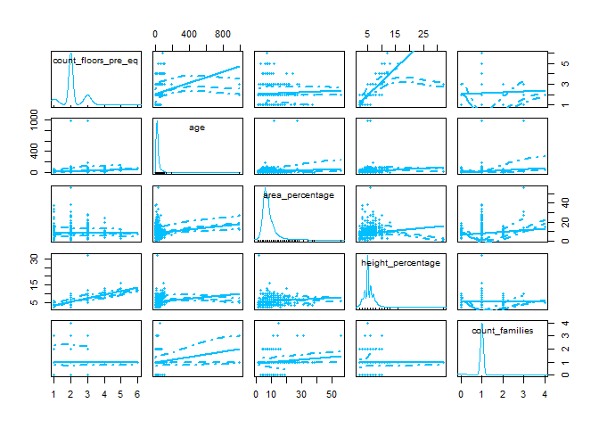

```r
scatterplotMatrix(train_values.numeric %>% head(1000), pch=20, col="deepskyblue")
```

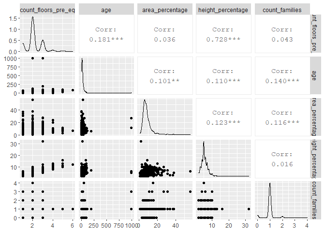

```r
ggpairs(train_values.numeric %>% head(1000))
```

# 3 Análisis sobre las distribuciones

Shapiro-Wilk Normality test:

```r
normality(train_values.numeric) %>% filter(p_value < 0.05)
```

| vars | statistic | p_value | sample |
| --- | --- | --- | --- |
| count_floors_pre_eq | 0.7982636 | 9.426235e-62 | 5000 |
| age | 0.1938435 | 8.111120e-91 | 5000 |
| area_percentage | 0.8056647 | 4.778498e-61 | 5000 |
| height_percentage | 0.8965860 | 8.906923e-50 | 5000 |
| count_families | 0.4836144 | 7.561213e-81 | 5000 |

Ninguna de las variables numéricas es normal.

Gráficos Q-Q para verlo mejor:

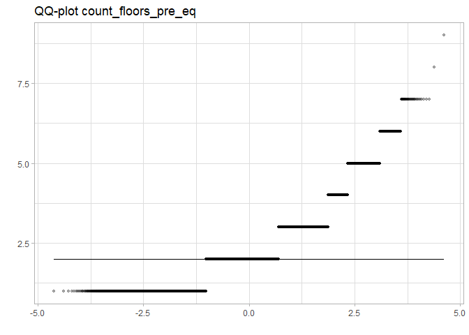

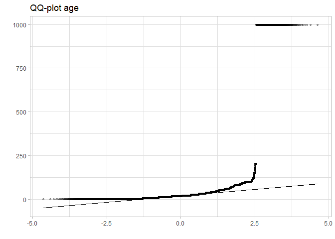

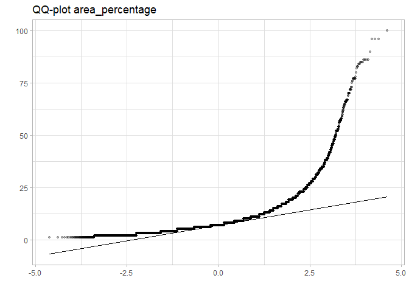

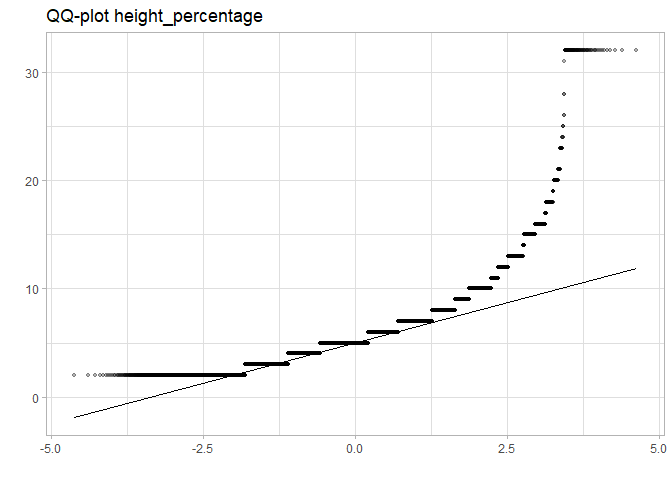

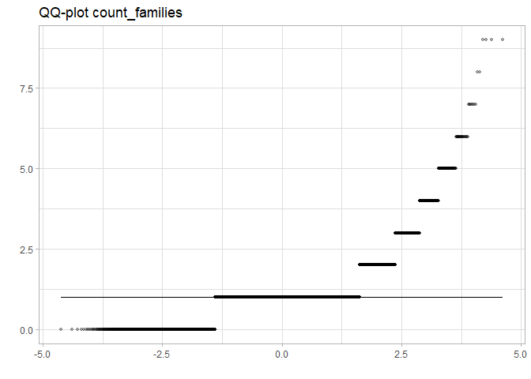

```r
x<-rnorm(100, mean=0, sd=1)

plt <- list(length = length(names.numeric))

for (i in 1:length(names.numeric)) {
  ggplot(train_values.numeric, aes_string(sample=names.numeric[i])) +
    stat_qq(alpha=.3, fill=colors[i], size=1) +
    stat_qq_line() +
    labs(title="", x="", y="") +
    theme_light() -> plt[[i]]

  print(plt[[i]] + labs(title=sprintf("QQ-plot %s", names.numeric[i]), x=""))
}
```

Skewness:

```r
skewCols <- find_skewness(train_values)
colnames(train_values)[skewCols]
```

```
[1] "count_floors_pre_eq" "age"                 "area_percentage"
[4] "height_percentage"   "count_families"
```

Clases desbalanceadas

```r
table(train_labels$damage_grade)
cat("\nPorcentajes:")
round(prop.table(table(train_labels$damage_grade))*100,2)
```

```
     1      2      3
 25124 148259  87218

Porcentajes:
    1     2     3
 9.64 56.89 33.47
```

# 4 Análisis de correlación

Solo de las variables numéricas

Corrplot

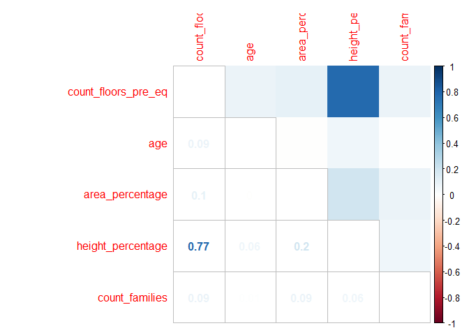

```r
cor(train_values.numeric) %>%
  corrplot.mixed(tl.pos="lt", upper="color", mar=c(0,0,1,0))
```

# 5 Duplicados

El dataset cuenta con valores repetidos

```r
sum(duplicated(train_values))
```

```
[1] 16191
```

Muchas intancias duplicadas, hay que ver qué hacer con ellas

```r
train_values[which(duplicated(train_values)),] %>% arrange(geo_level_3_id)

cat("Count_families de duplicados:\n")
train_values[which(duplicated(train_values)),]$count_families %>% table()
```

| geo_level_1_id | geo_level_2_id | geo_level_3_id | count_floors_pre_eq | age | area_percentage | height_percentage | land_surface_condition | foundation_type | roof_type | ground_floor_type | other_floor_type | position | plan_configuration | has_superstructure_adobe_mud | has_superstructure_mud_mortar_stone | has_superstructure_stone_flag | has_superstructure_cement_mortar_stone | has_superstructure_mud_mortar_brick | has_superstructure_cement_mortar_brick | has_superstructure_timber | has_superstructure_bamboo | has_superstructure_rc_non_engineered | has_superstructure_rc_engineered | has_superstructure_other | legal_ownership_status | count_families | has_secondary_use | has_secondary_use_agriculture | has_secondary_use_hotel | … |
| --- | --- | --- | --- | --- | --- | --- | --- | --- | --- | --- | --- | --- | --- | --- | --- | --- | --- | --- | --- | --- | --- | --- | --- | --- | --- | --- | --- | --- | --- | --- |
| 1 | 14 | 5 | 2 | 25 | 4 | 4 | t | r | q | f | q | s | d | 0 | 1 | 0 | 0 | 0 | 0 | 0 | 0 | 1 | 0 | 0 | v | 1 | 0 | 0 | 0 | … |
| 20 | 1378 | 8 | 2 | 15 | 8 | 5 | n | r | n | f | q | s | d | 0 | 1 | 0 | 0 | 0 | 0 | 0 | 0 | 0 | 0 | 0 | v | 1 | 0 | 0 | 0 | … |
| 20 | 1378 | 8 | 3 | 10 | 8 | 5 | n | r | n | f | q | s | d | 0 | 1 | 0 | 0 | 0 | 0 | 0 | 0 | 0 | 0 | 0 | v | 1 | 0 | 0 | 0 | … |
| 20 | 1378 | 8 | 2 | 20 | 8 | 5 | n | r | n | f | q | s | d | 0 | 1 | 0 | 0 | 0 | 0 | 0 | 0 | 0 | 0 | 0 | v | 1 | 0 | 0 | 0 | … |
| 8 | 597 | 11 | 2 | 10 | 5 | 5 | t | r | n | f | q | s | d | 0 | 1 | 0 | 0 | 0 | 0 | 0 | 0 | 0 | 0 | 0 | v | 1 | 0 | 0 | 0 | … |
| 8 | 597 | 11 | 2 | 10 | 6 | 5 | t | r | n | f | q | s | d | 0 | 1 | 0 | 0 | 0 | 0 | 0 | 0 | 0 | 0 | 0 | v | 1 | 0 | 0 | 0 | … |
| 8 | 597 | 11 | 2 | 20 | 6 | 5 | t | r | n | f | q | s | d | 0 | 1 | 0 | 0 | 0 | 0 | 0 | 0 | 0 | 0 | 0 | v | 1 | 0 | 0 | 0 | … |
| 8 | 597 | 11 | 2 | 5 | 6 | 5 | t | r | n | f | q | s | d | 0 | 1 | 0 | 0 | 0 | 0 | 0 | 0 | 0 | 0 | 0 | v | 1 | 0 | 0 | 0 | … |
| 8 | 597 | 11 | 2 | 15 | 6 | 5 | t | r | n | f | q | s | d | 0 | 1 | 0 | 0 | 0 | 0 | 0 | 0 | 0 | 0 | 0 | v | 1 | 0 | 0 | 0 | … |
| 8 | 597 | 11 | 2 | 20 | 6 | 5 | t | r | n | f | q | t | d | 0 | 1 | 0 | 0 | 0 | 0 | 0 | 0 | 0 | 0 | 0 | v | 1 | 0 | 0 | 0 | … |

[output cut: 9990 more lines]

```
Count_families de duplicados:
.
    0     1     2     3     4
  203 15861   122     4     1
```

# 6 Transformaciones

Siempre se puede estandarizar los datos, no se pierde nada.

# 7 Conclusiones

  Sorprendía que se repitieran por el count_families, pero la mayoría son de 1 sola (supongo que serán casas).

  Habría que ver qué hacer con estos duplicados.
- Los geo_level_2 y 3 quizás se pueden agrupar por intervalos, o directamente quitar.
- Para árboles/reglas, las flags se deberían agrupar
- Age también se podría agrupar en intervalos